# Analise_Dados_2023

Lis Cavalheiro

2025-11-24

# Introdução

Este relatório apresenta uma análise exploratória dos atributos florais da espécie Oenothera ravanii coletados no ano de 2023.

As variáveis no dataset são:

- id: identificador único
- area: área floral
- tubo: comprimento do tubo floral
- antera: altura da antera
- estigma: altura do estigma
- nsem: número de sementes
- germ: taxa de germinação

# Descrição

Para as possíveis análises dos dados do presente projeto, vamos carregá-los, separadamente, por ano. Nesse sentido, procuramos maior organização e entendimento dos dados acerca dos atributos morfológicos funcionais das flores da espécie Oenothera ravenii em um prazo de 9 anos. Este arquivo, em especial, trabalha medidas estatísticas dos dados relativos ao ano de 2023 (arquivo: “Dados_Oenothera_2023.csv”)

# Carregamento dos dados

```r
library(tidyverse) # biblioteca necessária
df <- read.csv("Dados/Dados_Oenothera_2023.csv") # cria o df

head(df) # visualiza os primeiros valores do DataFrame
```

```
##   id area tubo antera estigma nsem germ
## 1  1 59.7 46.0   34.6    42.5    6   NA
## 2  2 51.2 44.6   31.5    38.9  121  0.8
## 3  3 59.2 50.1   29.7    38.9   57  1.0
## 4  4 43.2 45.7   27.0    38.5  241  0.6
## 5  5 43.5 50.3   29.2    40.5    0  0.0
## 6  6 60.9 52.1   32.0    45.1  235  0.9
```

# Verificando se existem dados faltantes

```r
glimpse(df) # geral
```

```
## Rows: 79
## Columns: 7
## $ id      <int> 1, 2, 3, 4, 5, 6, 7, 8, 9, 10, 11, 12, 13, 14, 15, 16, 17, 18,…
## $ area    <dbl> 59.7, 51.2, 59.2, 43.2, 43.5, 60.9, 53.4, 54.9, 57.7, 67.1, 67…
## $ tubo    <dbl> 46.0, 44.6, 50.1, 45.7, 50.3, 52.1, 42.7, 46.1, 48.8, 53.9, 44…
## $ antera  <dbl> 34.6, 31.5, 29.7, 27.0, 29.2, 32.0, 30.3, 29.8, 28.9, 28.1, 28…
## $ estigma <dbl> 42.5, 38.9, 38.9, 38.5, 40.5, 45.1, 39.2, 39.0, 41.9, 42.1, 44…
## $ nsem    <int> 6, 121, 57, 241, 0, 235, 188, 185, 236, 309, 279, 370, 60, 203…
## $ germ    <dbl> NA, 0.8, 1.0, 0.6, 0.0, 0.9, 1.0, 0.8, 1.0, 1.0, 1.0, 1.0, 1.0…
```

```r
colSums(is.na(df)) # contagem de NAs por variável
```

```
##      id    area    tubo  antera estigma    nsem    germ
##       0       0       0       0       0       0       6
```

A variável “germ” possui 6 valores NA, e a variável “nsem” apresenta zeros que representam ausência de atributo. Vamos manter os zeros em “nsem” e substituir os valores NAs de “germ” por 0, que indica não germinação.

```r
df_clean <- df %>%
  mutate(germ = ifelse(is.na(germ), 0, germ)) # troca valores ausentes por 0

colSums(is.na(df_clean)) # verifica se ainda existem NAs
```

```
##      id    area    tubo  antera estigma    nsem    germ
##       0       0       0       0       0       0       0
```

# Estatísticas Descritivas

```r
summary(df_clean) # descrição geral dos dados
```

```
##        id            area            tubo           antera         estigma
##  Min.   : 1.0   Min.   :18.70   Min.   :34.20   Min.   :15.10   Min.   :21.20
##  1st Qu.:20.5   1st Qu.:51.05   1st Qu.:44.95   1st Qu.:25.85   1st Qu.:36.70
##  Median :40.0   Median :58.50   Median :48.00   Median :28.70   Median :39.80
##  Mean   :40.0   Mean   :58.49   Mean   :47.84   Mean   :28.26   Mean   :39.21
##  3rd Qu.:59.5   3rd Qu.:67.35   3rd Qu.:50.40   3rd Qu.:31.00   3rd Qu.:42.25
##  Max.   :79.0   Max.   :92.80   Max.   :61.30   Max.   :35.90   Max.   :49.60
##       nsem            germ
##  Min.   :  0.0   Min.   :0.0000
##  1st Qu.: 92.5   1st Qu.:0.6000
##  Median :216.0   Median :0.9000
##  Mean   :206.1   Mean   :0.6962
##  3rd Qu.:315.0   3rd Qu.:1.0000
##  Max.   :465.0   Max.   :1.0000
```

```r
df_clean %>%
  summarise(
    media_area = mean(area, na.rm = TRUE), # média - área floral
    sd_area = sd(area, na.rm = TRUE), # desvio padrão
    media_tubo = mean(tubo, na.rm = TRUE), # média - comprimento
    media_nsem = mean(nsem, na.rm = TRUE), # média - n. sementes
    media_germ = mean(germ, na.rm = TRUE) # média - germinação
  )
```

```
##   media_area  sd_area media_tubo media_nsem media_germ
## 1   58.48608 13.70131    47.8443   206.0633  0.6962025
```

# Visualizações

## Distribuição das variáveis

```r
library(dplyr) # manipulação de dados
library(tidyr) # transformação de dados largos e longos
library(ggplot2) # confecção de gráficos
```

Nesta etapa, para a confecção dos gráficos de distribuição das variáveis, os nomes das colunas foram alterados para que os labels fiquem mais claros e informativos, além de evitar problemas com acentuação:

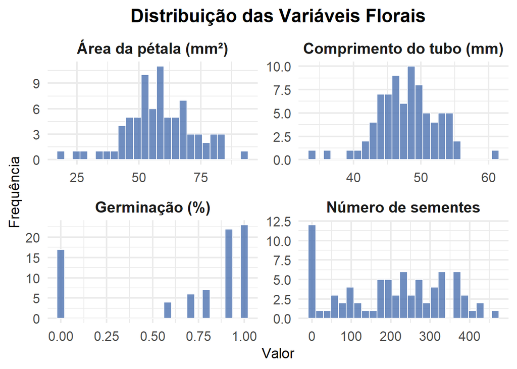

```r
# Renomear variáveis sem acentos
df_clean_plot <- df_clean %>%
  rename(
    Area_mm2 = area,
    Comprimento_tubo_mm = tubo,
    Altura_antera_mm = antera,
    Altura_estigma_mm = estigma,
    Numero_sementes = nsem,
    Germinacao = germ
  )

df_clean_plot %>% # conversão para o formato longo
  pivot_longer(
    cols = c(Area_mm2, Comprimento_tubo_mm, Numero_sementes, Germinacao),
    names_to = "Variavel",
    values_to = "Valor"
  ) %>%
    mutate(
    Variavel = recode(
      Variavel,
      "Area_mm2" = "Área da pétala (mm²)",
      "Comprimento_tubo_mm" = "Comprimento do tubo (mm)",
      "Numero_sementes" = "Número de sementes",
      "Germinacao" = "Germinação (%)"
    )
  ) %>%
  ggplot(aes(x = Valor)) + # inicia o gráfico
  geom_histogram(
    bins = 25,
    fill = "#4C72B0",
    color = "white",
    alpha = 0.8
  ) +
  facet_wrap(~ Variavel, scales = "free", ncol = 2) + # um gráfico para cada variável
  labs(
    title = "Distribuição das Variáveis Florais",
    x = "Valor",
    y = "Frequência"
  ) +
  theme_minimal(base_size = 16) +
  theme(
    plot.title = element_text(face = "bold", size = 18, hjust = 0.5),
    strip.text = element_text(size = 15, face = "bold"),
    axis.title.x = element_text(size = 14),
    axis.title.y = element_text(size = 14)
  )
```

## Relação entre área floral e germinação

Vamos construir um boxplot para visualização das duas variáveis: “Área Floral” e “Germinação”

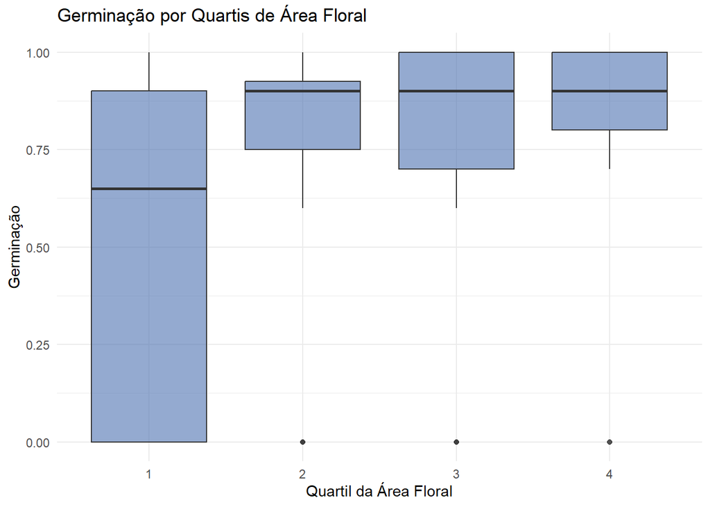

```r
df_clean %>%
  mutate(area_cat = ntile(area, 4)) %>%   # divide em quartis
  ggplot(aes(x = factor(area_cat), y = germ)) +
  geom_boxplot(fill="#4C72B0", alpha=.6) +
  labs(
    x = "Quartil da Área Floral",
    y = "Germinação",
    title = "Germinação por Quartis de Área Floral"
  ) +
  theme_minimal()
```

## Relação entre número de sementes e germinação

Vamos construir um boxplot para visualização das duas variáveis: “Número de Sementes” e “Germinação”

```r
names(df_clean)
```

```
## [1] "id"      "area"    "tubo"    "antera"  "estigma" "nsem"    "germ"
```

```r
summary(df_clean)
```

```
##        id            area            tubo           antera         estigma
##  Min.   : 1.0   Min.   :18.70   Min.   :34.20   Min.   :15.10   Min.   :21.20
##  1st Qu.:20.5   1st Qu.:51.05   1st Qu.:44.95   1st Qu.:25.85   1st Qu.:36.70
##  Median :40.0   Median :58.50   Median :48.00   Median :28.70   Median :39.80
##  Mean   :40.0   Mean   :58.49   Mean   :47.84   Mean   :28.26   Mean   :39.21
##  3rd Qu.:59.5   3rd Qu.:67.35   3rd Qu.:50.40   3rd Qu.:31.00   3rd Qu.:42.25
##  Max.   :79.0   Max.   :92.80   Max.   :61.30   Max.   :35.90   Max.   :49.60
##       nsem            germ
##  Min.   :  0.0   Min.   :0.0000
##  1st Qu.: 92.5   1st Qu.:0.6000
##  Median :216.0   Median :0.9000
##  Mean   :206.1   Mean   :0.6962
##  3rd Qu.:315.0   3rd Qu.:1.0000
##  Max.   :465.0   Max.   :1.0000
```

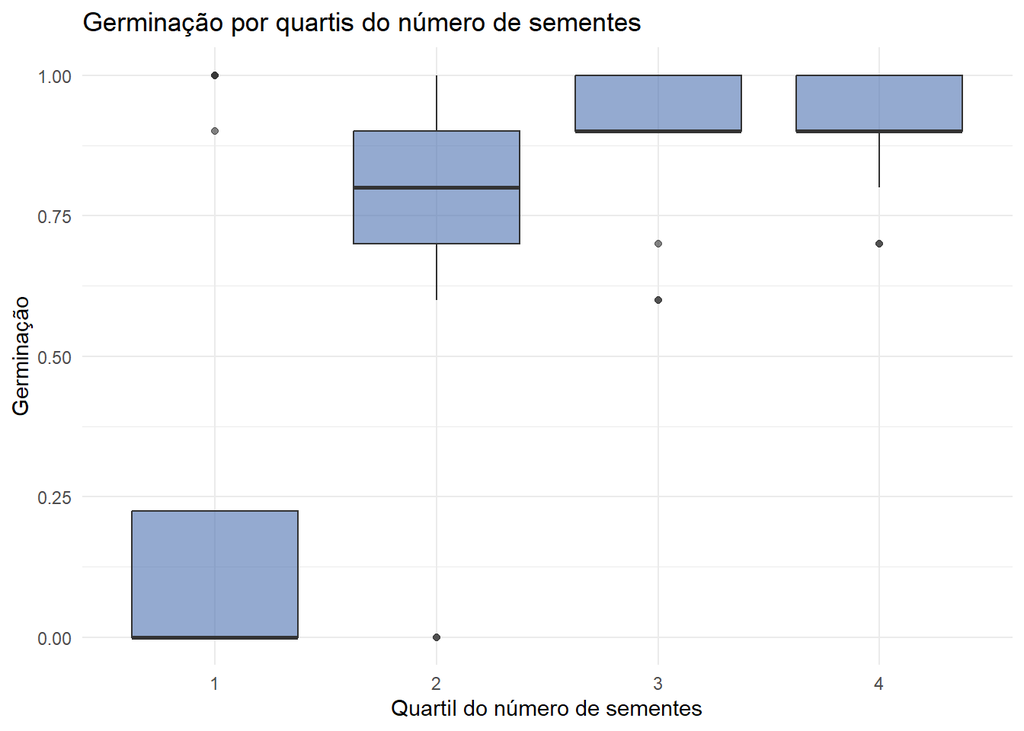

```r
df_clean %>%
  mutate(quartil_nsem = ntile(nsem, 4)) %>% # divide em quartis
  ggplot(aes(x = factor(quartil_nsem), y = germ)) +
  geom_boxplot(fill="#4C72B0", alpha=.6) +
  labs(
    title = "Germinação por quartis do número de sementes",
    x = "Quartil do número de sementes",
    y = "Germinação"
  ) +
  theme_minimal()
```

- O número de sementes é um forte preditor do sucesso de Germinação. A chance de germinação é praticamente nula no quartil com o menor número de sementes (Q1). A Germinação aumenta drasticamente assim que um número mínimo de sementes é produzido. No entanto, a mediana de Germinação não aumenta linearmente com o aumento do número de sementes, mas aparenta atingir um platô, já que os quartir 3 e 4 sobrepoem as duas distribuições de taxa de germinação.